# Hotel Booking Analysis

## Import Libraries

```python
import numpy as np
import pandas as pd
import matplotlib.pyplot as plt
import seaborn as sns
%matplotlib inline
```

## Loading Dataset

```python
df=pd.read_csv(r'C:\Users\yunge\Desktop\Data Science\Python\Data Analysis Projects\Hotel Booking Analysis\hotel_bookings.csv')
df.head()
```

|  | hotel | is_canceled | lead_time | arrival_date_year | arrival_date_month | arrival_date_week_number | arrival_date_day_of_month | stays_in_weekend_nights | stays_in_week_nights | adults | ... | deposit_type | agent | company | days_in_waiting_list | customer_type | adr | required_car_parking_spaces | total_of_special_requests | reservation_status | reservation_status_date |
| --- | --- | --- | --- | --- | --- | --- | --- | --- | --- | --- | --- | --- | --- | --- | --- | --- | --- | --- | --- | --- | --- |
| 0 | Resort Hotel | 0 | 342 | 2015 | July | 27 | 1 | 0 | 0 | 2 | ... | No Deposit | NaN | NaN | 0 | Transient | 0.0 | 0 | 0 | Check-Out | 7/1/2015 |
| 1 | Resort Hotel | 0 | 737 | 2015 | July | 27 | 1 | 0 | 0 | 2 | ... | No Deposit | NaN | NaN | 0 | Transient | 0.0 | 0 | 0 | Check-Out | 7/1/2015 |
| 2 | Resort Hotel | 0 | 7 | 2015 | July | 27 | 1 | 0 | 1 | 1 | ... | No Deposit | NaN | NaN | 0 | Transient | 75.0 | 0 | 0 | Check-Out | 7/2/2015 |
| 3 | Resort Hotel | 0 | 13 | 2015 | July | 27 | 1 | 0 | 1 | 1 | ... | No Deposit | 304.0 | NaN | 0 | Transient | 75.0 | 0 | 0 | Check-Out | 7/2/2015 |
| 4 | Resort Hotel | 0 | 14 | 2015 | July | 27 | 1 | 0 | 2 | 2 | ... | No Deposit | 240.0 | NaN | 0 | Transient | 98.0 | 0 | 1 | Check-Out | 7/3/2015 |

5 rows × 32 columns

## Data Preperation

```python
df.shape
```

```
(119390, 32)
```

```python
df.isnull().values.any()
```

```
True
```

```python
df.isnull().sum()
```

```
hotel                                  0
is_canceled                            0
lead_time                              0
arrival_date_year                      0
arrival_date_month                     0
arrival_date_week_number               0
arrival_date_day_of_month              0
stays_in_weekend_nights                0
stays_in_week_nights                   0
adults                                 0
children                               4
babies                                 0
meal                                   0
country                              488
market_segment                         0
distribution_channel                   0
is_repeated_guest                      0
previous_cancellations                 0
previous_bookings_not_canceled         0
reserved_room_type                     0
assigned_room_type                     0
booking_changes                        0
deposit_type                           0
agent                              16340
company                           112593
days_in_waiting_list                   0
customer_type                          0
adr                                    0
required_car_parking_spaces            0
total_of_special_requests              0
reservation_status                     0
reservation_status_date                0
dtype: int64
```

```python
# Fill the null values with 0
df.fillna(0,inplace=True)
```

```python
df.isna().sum()
```

```
hotel                             0
is_canceled                       0
lead_time                         0
arrival_date_year                 0
arrival_date_month                0
arrival_date_week_number          0
arrival_date_day_of_month         0
stays_in_weekend_nights           0
stays_in_week_nights              0
adults                            0
children                          0
babies                            0
meal                              0
country                           0
market_segment                    0
distribution_channel              0
is_repeated_guest                 0
previous_cancellations            0
previous_bookings_not_canceled    0
reserved_room_type                0
assigned_room_type                0
booking_changes                   0
deposit_type                      0
agent                             0
company                           0
days_in_waiting_list              0
customer_type                     0
adr                               0
required_car_parking_spaces       0
total_of_special_requests         0
reservation_status                0
reservation_status_date           0
dtype: int64
```

```python
df['meal'].value_counts()
```

```
BB           92310
HB           14463
SC           10650
Undefined     1169
FB             798
Name: meal, dtype: int64
```

```python
df['meal'].unique()
```

```
array(['BB', 'FB', 'HB', 'SC', 'Undefined'], dtype=object)
```

```python
df['adults'].unique()
```

```
array([ 2,  1,  3,  4, 40, 26, 50, 27, 55,  0, 20,  6,  5, 10],
      dtype=int64)
```

```python
df['children'].unique()
```

```
array([ 0.,  1.,  2., 10.,  3.])
```

```python
df['babies'].unique()
```

```
array([ 0,  1,  2, 10,  9], dtype=int64)
```

```python
# There are 180 rows which have 0 as entry for all 3 columns 'adults, children and babies', indicating these are wrong entries as there are no guest who checked into the hotel
filter=(df['adults']==0) & (df['children']==0) & (df['babies']==0)
df[filter]
```

|  | hotel | is_canceled | lead_time | arrival_date_year | arrival_date_month | arrival_date_week_number | arrival_date_day_of_month | stays_in_weekend_nights | stays_in_week_nights | adults | ... | deposit_type | agent | company | days_in_waiting_list | customer_type | adr | required_car_parking_spaces | total_of_special_requests | reservation_status | reservation_status_date |
| --- | --- | --- | --- | --- | --- | --- | --- | --- | --- | --- | --- | --- | --- | --- | --- | --- | --- | --- | --- | --- | --- |
| 2224 | Resort Hotel | 0 | 1 | 2015 | October | 41 | 6 | 0 | 3 | 0 | ... | No Deposit | 0.0 | 174.0 | 0 | Transient-Party | 0.00 | 0 | 0 | Check-Out | 10/6/2015 |
| 2409 | Resort Hotel | 0 | 0 | 2015 | October | 42 | 12 | 0 | 0 | 0 | ... | No Deposit | 0.0 | 174.0 | 0 | Transient | 0.00 | 0 | 0 | Check-Out | 10/12/2015 |
| 3181 | Resort Hotel | 0 | 36 | 2015 | November | 47 | 20 | 1 | 2 | 0 | ... | No Deposit | 38.0 | 0.0 | 0 | Transient-Party | 0.00 | 0 | 0 | Check-Out | 11/23/2015 |
| 3684 | Resort Hotel | 0 | 165 | 2015 | December | 53 | 30 | 1 | 4 | 0 | ... | No Deposit | 308.0 | 0.0 | 122 | Transient-Party | 0.00 | 0 | 0 | Check-Out | 1/4/2016 |
| 3708 | Resort Hotel | 0 | 165 | 2015 | December | 53 | 30 | 2 | 4 | 0 | ... | No Deposit | 308.0 | 0.0 | 122 | Transient-Party | 0.00 | 0 | 0 | Check-Out | 1/5/2016 |
| ... | ... | ... | ... | ... | ... | ... | ... | ... | ... | ... | ... | ... | ... | ... | ... | ... | ... | ... | ... | ... | ... |
| 115029 | City Hotel | 0 | 107 | 2017 | June | 26 | 27 | 0 | 3 | 0 | ... | No Deposit | 7.0 | 0.0 | 0 | Transient | 100.80 | 0 | 0 | Check-Out | 6/30/2017 |
| 115091 | City Hotel | 0 | 1 | 2017 | June | 26 | 30 | 0 | 1 | 0 | ... | No Deposit | 0.0 | 0.0 | 0 | Transient | 0.00 | 1 | 1 | Check-Out | 7/1/2017 |
| 116251 | City Hotel | 0 | 44 | 2017 | July | 28 | 15 | 1 | 1 | 0 | ... | No Deposit | 425.0 | 0.0 | 0 | Transient | 73.80 | 0 | 0 | Check-Out | 7/17/2017 |
| 116534 | City Hotel | 0 | 2 | 2017 | July | 28 | 15 | 2 | 5 | 0 | ... | No Deposit | 9.0 | 0.0 | 0 | Transient-Party | 22.86 | 0 | 1 | Check-Out | 7/22/2017 |
| 117087 | City Hotel | 0 | 170 | 2017 | July | 30 | 27 | 0 | 2 | 0 | ... | No Deposit | 52.0 | 0.0 | 0 | Transient | 0.00 | 0 | 0 | Check-Out | 7/29/2017 |

180 rows × 32 columns

```python
# There are 119,210 rows left after calling the filter; ~ as negation
df[~filter]
```

|  | hotel | is_canceled | lead_time | arrival_date_year | arrival_date_month | arrival_date_week_number | arrival_date_day_of_month | stays_in_weekend_nights | stays_in_week_nights | adults | ... | deposit_type | agent | company | days_in_waiting_list | customer_type | adr | required_car_parking_spaces | total_of_special_requests | reservation_status | reservation_status_date |
| --- | --- | --- | --- | --- | --- | --- | --- | --- | --- | --- | --- | --- | --- | --- | --- | --- | --- | --- | --- | --- | --- |
| 0 | Resort Hotel | 0 | 342 | 2015 | July | 27 | 1 | 0 | 0 | 2 | ... | No Deposit | 0.0 | 0.0 | 0 | Transient | 0.00 | 0 | 0 | Check-Out | 7/1/2015 |
| 1 | Resort Hotel | 0 | 737 | 2015 | July | 27 | 1 | 0 | 0 | 2 | ... | No Deposit | 0.0 | 0.0 | 0 | Transient | 0.00 | 0 | 0 | Check-Out | 7/1/2015 |
| 2 | Resort Hotel | 0 | 7 | 2015 | July | 27 | 1 | 0 | 1 | 1 | ... | No Deposit | 0.0 | 0.0 | 0 | Transient | 75.00 | 0 | 0 | Check-Out | 7/2/2015 |
| 3 | Resort Hotel | 0 | 13 | 2015 | July | 27 | 1 | 0 | 1 | 1 | ... | No Deposit | 304.0 | 0.0 | 0 | Transient | 75.00 | 0 | 0 | Check-Out | 7/2/2015 |
| 4 | Resort Hotel | 0 | 14 | 2015 | July | 27 | 1 | 0 | 2 | 2 | ... | No Deposit | 240.0 | 0.0 | 0 | Transient | 98.00 | 0 | 1 | Check-Out | 7/3/2015 |
| ... | ... | ... | ... | ... | ... | ... | ... | ... | ... | ... | ... | ... | ... | ... | ... | ... | ... | ... | ... | ... | ... |
| 119385 | City Hotel | 0 | 23 | 2017 | August | 35 | 30 | 2 | 5 | 2 | ... | No Deposit | 394.0 | 0.0 | 0 | Transient | 96.14 | 0 | 0 | Check-Out | 9/6/2017 |
| 119386 | City Hotel | 0 | 102 | 2017 | August | 35 | 31 | 2 | 5 | 3 | ... | No Deposit | 9.0 | 0.0 | 0 | Transient | 225.43 | 0 | 2 | Check-Out | 9/7/2017 |
| 119387 | City Hotel | 0 | 34 | 2017 | August | 35 | 31 | 2 | 5 | 2 | ... | No Deposit | 9.0 | 0.0 | 0 | Transient | 157.71 | 0 | 4 | Check-Out | 9/7/2017 |
| 119388 | City Hotel | 0 | 109 | 2017 | August | 35 | 31 | 2 | 5 | 2 | ... | No Deposit | 89.0 | 0.0 | 0 | Transient | 104.40 | 0 | 0 | Check-Out | 9/7/2017 |
| 119389 | City Hotel | 0 | 205 | 2017 | August | 35 | 29 | 2 | 7 | 2 | ... | No Deposit | 9.0 | 0.0 | 0 | Transient | 151.20 | 0 | 2 | Check-Out | 9/7/2017 |

119210 rows × 32 columns

```python
# This will be our processed data and we will be using this dataset for further analysis
data=df[~filter]
```

```python
data.shape
```

```
(119210, 32)
```

## Spatial Analysis on Guests' Hometown

```python
df['hotel'].unique()
```

```
array(['Resort Hotel', 'City Hotel'], dtype=object)
```

```python
df['is_canceled'].unique()
```

```
array([0, 1], dtype=int64)
```

```python
resort=data[(data['hotel']=='Resort Hotel') & (data['is_canceled']==0)]
city=data[(data['hotel']=='City Hotel') & (data['is_canceled']==0)]
```

```python
resort.head()
```

|  | hotel | is_canceled | lead_time | arrival_date_year | arrival_date_month | arrival_date_week_number | arrival_date_day_of_month | stays_in_weekend_nights | stays_in_week_nights | adults | ... | deposit_type | agent | company | days_in_waiting_list | customer_type | adr | required_car_parking_spaces | total_of_special_requests | reservation_status | reservation_status_date |
| --- | --- | --- | --- | --- | --- | --- | --- | --- | --- | --- | --- | --- | --- | --- | --- | --- | --- | --- | --- | --- | --- |
| 0 | Resort Hotel | 0 | 342 | 2015 | July | 27 | 1 | 0 | 0 | 2 | ... | No Deposit | 0.0 | 0.0 | 0 | Transient | 0.0 | 0 | 0 | Check-Out | 7/1/2015 |
| 1 | Resort Hotel | 0 | 737 | 2015 | July | 27 | 1 | 0 | 0 | 2 | ... | No Deposit | 0.0 | 0.0 | 0 | Transient | 0.0 | 0 | 0 | Check-Out | 7/1/2015 |
| 2 | Resort Hotel | 0 | 7 | 2015 | July | 27 | 1 | 0 | 1 | 1 | ... | No Deposit | 0.0 | 0.0 | 0 | Transient | 75.0 | 0 | 0 | Check-Out | 7/2/2015 |
| 3 | Resort Hotel | 0 | 13 | 2015 | July | 27 | 1 | 0 | 1 | 1 | ... | No Deposit | 304.0 | 0.0 | 0 | Transient | 75.0 | 0 | 0 | Check-Out | 7/2/2015 |
| 4 | Resort Hotel | 0 | 14 | 2015 | July | 27 | 1 | 0 | 2 | 2 | ... | No Deposit | 240.0 | 0.0 | 0 | Transient | 98.0 | 0 | 1 | Check-Out | 7/3/2015 |

5 rows × 32 columns

```python
city.head()
```

|  | hotel | is_canceled | lead_time | arrival_date_year | arrival_date_month | arrival_date_week_number | arrival_date_day_of_month | stays_in_weekend_nights | stays_in_week_nights | adults | ... | deposit_type | agent | company | days_in_waiting_list | customer_type | adr | required_car_parking_spaces | total_of_special_requests | reservation_status | reservation_status_date |
| --- | --- | --- | --- | --- | --- | --- | --- | --- | --- | --- | --- | --- | --- | --- | --- | --- | --- | --- | --- | --- | --- |
| 40060 | City Hotel | 0 | 6 | 2015 | July | 27 | 1 | 0 | 2 | 1 | ... | No Deposit | 6.0 | 0.0 | 0 | Transient | 0.00 | 0 | 0 | Check-Out | 7/3/2015 |
| 40066 | City Hotel | 0 | 3 | 2015 | July | 27 | 2 | 0 | 3 | 1 | ... | No Deposit | 1.0 | 0.0 | 0 | Transient-Party | 58.67 | 0 | 0 | Check-Out | 7/5/2015 |
| 40070 | City Hotel | 0 | 43 | 2015 | July | 27 | 3 | 0 | 2 | 2 | ... | No Deposit | 1.0 | 0.0 | 0 | Transient-Party | 86.00 | 0 | 0 | Check-Out | 7/5/2015 |
| 40071 | City Hotel | 0 | 43 | 2015 | July | 27 | 3 | 0 | 2 | 2 | ... | No Deposit | 1.0 | 0.0 | 0 | Transient-Party | 43.00 | 0 | 0 | Check-Out | 7/5/2015 |
| 40072 | City Hotel | 0 | 43 | 2015 | July | 27 | 3 | 0 | 2 | 2 | ... | No Deposit | 1.0 | 0.0 | 0 | Transient-Party | 86.00 | 0 | 0 | Check-Out | 7/5/2015 |

5 rows × 32 columns

```python
resort.shape
```

```
(28927, 32)
```

```python
city.shape
```

```
(46084, 32)
```

## Import Plotly

```python
pip install plotly
```

```python
import plotly.graph_objs as go
from plotly.offline import iplot
import plotly.express as px
```

```python
labels=resort['country'].value_counts().index
values=resort['country'].value_counts()
```

```python
fig=px.pie(values=values,
             names=labels,
             title="Home Country of Guests for Resort Hotel",
             template="seaborn")

fig.update_traces(textposition="inside", textinfo="value+percent+label")
fig.show()
```

[interactive chart not shown]

```python
labels2=city['country'].value_counts().index
values2=city['country'].value_counts()

fig=px.pie(values=values2,
             names=labels2,
             title="Home Country of Guests for City Hotel",
             template="seaborn")

fig.update_traces(textposition="inside", textinfo="value+percent+label")
fig.show()
```

[interactive chart not shown]

```python
# A dataframe where is_canceled equals 0, including both resort hotel and city hotel
data[data['is_canceled']==0]
```

|  | hotel | is_canceled | lead_time | arrival_date_year | arrival_date_month | arrival_date_week_number | arrival_date_day_of_month | stays_in_weekend_nights | stays_in_week_nights | adults | ... | deposit_type | agent | company | days_in_waiting_list | customer_type | adr | required_car_parking_spaces | total_of_special_requests | reservation_status | reservation_status_date |
| --- | --- | --- | --- | --- | --- | --- | --- | --- | --- | --- | --- | --- | --- | --- | --- | --- | --- | --- | --- | --- | --- |
| 0 | Resort Hotel | 0 | 342 | 2015 | July | 27 | 1 | 0 | 0 | 2 | ... | No Deposit | 0.0 | 0.0 | 0 | Transient | 0.00 | 0 | 0 | Check-Out | 7/1/2015 |
| 1 | Resort Hotel | 0 | 737 | 2015 | July | 27 | 1 | 0 | 0 | 2 | ... | No Deposit | 0.0 | 0.0 | 0 | Transient | 0.00 | 0 | 0 | Check-Out | 7/1/2015 |
| 2 | Resort Hotel | 0 | 7 | 2015 | July | 27 | 1 | 0 | 1 | 1 | ... | No Deposit | 0.0 | 0.0 | 0 | Transient | 75.00 | 0 | 0 | Check-Out | 7/2/2015 |
| 3 | Resort Hotel | 0 | 13 | 2015 | July | 27 | 1 | 0 | 1 | 1 | ... | No Deposit | 304.0 | 0.0 | 0 | Transient | 75.00 | 0 | 0 | Check-Out | 7/2/2015 |
| 4 | Resort Hotel | 0 | 14 | 2015 | July | 27 | 1 | 0 | 2 | 2 | ... | No Deposit | 240.0 | 0.0 | 0 | Transient | 98.00 | 0 | 1 | Check-Out | 7/3/2015 |
| ... | ... | ... | ... | ... | ... | ... | ... | ... | ... | ... | ... | ... | ... | ... | ... | ... | ... | ... | ... | ... | ... |
| 119385 | City Hotel | 0 | 23 | 2017 | August | 35 | 30 | 2 | 5 | 2 | ... | No Deposit | 394.0 | 0.0 | 0 | Transient | 96.14 | 0 | 0 | Check-Out | 9/6/2017 |
| 119386 | City Hotel | 0 | 102 | 2017 | August | 35 | 31 | 2 | 5 | 3 | ... | No Deposit | 9.0 | 0.0 | 0 | Transient | 225.43 | 0 | 2 | Check-Out | 9/7/2017 |
| 119387 | City Hotel | 0 | 34 | 2017 | August | 35 | 31 | 2 | 5 | 2 | ... | No Deposit | 9.0 | 0.0 | 0 | Transient | 157.71 | 0 | 4 | Check-Out | 9/7/2017 |
| 119388 | City Hotel | 0 | 109 | 2017 | August | 35 | 31 | 2 | 5 | 2 | ... | No Deposit | 89.0 | 0.0 | 0 | Transient | 104.40 | 0 | 0 | Check-Out | 9/7/2017 |
| 119389 | City Hotel | 0 | 205 | 2017 | August | 35 | 29 | 2 | 7 | 2 | ... | No Deposit | 9.0 | 0.0 | 0 | Transient | 151.20 | 0 | 2 | Check-Out | 9/7/2017 |

75011 rows × 32 columns

```python
# Currently country used as index
data[data['is_canceled']==0]['country'].value_counts()
```

```
PRT    20977
GBR     9668
FRA     8468
ESP     6383
DEU     6067
       ...
SLE        1
ATF        1
CYM        1
GUY        1
MAC        1
Name: country, Length: 166, dtype: int64
```

```python
# Reset index
country_data=data[data['is_canceled']==0]['country'].value_counts().reset_index()
country_data
```

|  | index | country |
| --- | --- | --- |
| 0 | PRT | 20977 |
| 1 | GBR | 9668 |
| 2 | FRA | 8468 |
| 3 | ESP | 6383 |
| 4 | DEU | 6067 |
| ... | ... | ... |
| 161 | SLE | 1 |
| 162 | ATF | 1 |
| 163 | CYM | 1 |
| 164 | GUY | 1 |
| 165 | MAC | 1 |

166 rows × 2 columns

```python
# Renaming columns of country_data
country_data.columns=['Country','Number of Guests']
country_data
```

|  | Country | Number of Guests |
| --- | --- | --- |
| 0 | PRT | 20977 |
| 1 | GBR | 9668 |
| 2 | FRA | 8468 |
| 3 | ESP | 6383 |
| 4 | DEU | 6067 |
| ... | ... | ... |
| 161 | SLE | 1 |
| 162 | ATF | 1 |
| 163 | CYM | 1 |
| 164 | GUY | 1 |
| 165 | MAC | 1 |

166 rows × 2 columns

```python
px.choropleth(country_data,
              locations=country_data['Country'],
              color=country_data['Number of Guests'],
              hover_name=country_data['Country'],
              title='Home Country of Guests')
```

[interactive chart not shown]

From the map above, we can conclude that majority of the hotel guests come from European countries.

## Hotel Pricing Analysis

```python
data.shape
```

```
(119210, 32)
```

```python
data.head()
```

|  | hotel | is_canceled | lead_time | arrival_date_year | arrival_date_month | arrival_date_week_number | arrival_date_day_of_month | stays_in_weekend_nights | stays_in_week_nights | adults | ... | deposit_type | agent | company | days_in_waiting_list | customer_type | adr | required_car_parking_spaces | total_of_special_requests | reservation_status | reservation_status_date |
| --- | --- | --- | --- | --- | --- | --- | --- | --- | --- | --- | --- | --- | --- | --- | --- | --- | --- | --- | --- | --- | --- |
| 0 | Resort Hotel | 0 | 342 | 2015 | July | 27 | 1 | 0 | 0 | 2 | ... | No Deposit | 0.0 | 0.0 | 0 | Transient | 0.0 | 0 | 0 | Check-Out | 7/1/2015 |
| 1 | Resort Hotel | 0 | 737 | 2015 | July | 27 | 1 | 0 | 0 | 2 | ... | No Deposit | 0.0 | 0.0 | 0 | Transient | 0.0 | 0 | 0 | Check-Out | 7/1/2015 |
| 2 | Resort Hotel | 0 | 7 | 2015 | July | 27 | 1 | 0 | 1 | 1 | ... | No Deposit | 0.0 | 0.0 | 0 | Transient | 75.0 | 0 | 0 | Check-Out | 7/2/2015 |
| 3 | Resort Hotel | 0 | 13 | 2015 | July | 27 | 1 | 0 | 1 | 1 | ... | No Deposit | 304.0 | 0.0 | 0 | Transient | 75.0 | 0 | 0 | Check-Out | 7/2/2015 |
| 4 | Resort Hotel | 0 | 14 | 2015 | July | 27 | 1 | 0 | 2 | 2 | ... | No Deposit | 240.0 | 0.0 | 0 | Transient | 98.0 | 0 | 1 | Check-Out | 7/3/2015 |

5 rows × 32 columns

```python
data.columns
```

```
Index(['hotel', 'is_canceled', 'lead_time', 'arrival_date_year',
       'arrival_date_month', 'arrival_date_week_number',
       'arrival_date_day_of_month', 'stays_in_weekend_nights',
       'stays_in_week_nights', 'adults', 'children', 'babies', 'meal',
       'country', 'market_segment', 'distribution_channel',
       'is_repeated_guest', 'previous_cancellations',
       'previous_bookings_not_canceled', 'reserved_room_type',
       'assigned_room_type', 'booking_changes', 'deposit_type', 'agent',
       'company', 'days_in_waiting_list', 'customer_type', 'adr',
       'required_car_parking_spaces', 'total_of_special_requests',
       'reservation_status', 'reservation_status_date'],
      dtype='object')
```

```python
data2=data[data['is_canceled']==0]
```

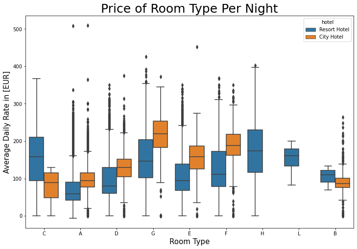

```python
# ADR as average daily rate
plt.figure(figsize=(12,8))
sns.boxplot(x='reserved_room_type',y='adr',data=data2,hue='hotel')
plt.title('Price of Room Type Per Night',fontsize=25)
plt.xlabel('Room Type',fontsize=15)
plt.ylabel('Average Daily Rate in [EUR]',fontsize=15)
```

```python
data_resort=resort[resort['is_canceled']==0]
data_city=city[city['is_canceled']==0]
```

```python
resort_mean=data_resort.groupby('arrival_date_month')['adr'].mean().reset_index()
resort_mean
```

|  | arrival_date_month | adr |
| --- | --- | --- |
| 0 | April | 75.867816 |
| 1 | August | 181.205892 |
| 2 | December | 68.410104 |
| 3 | February | 54.147478 |
| 4 | January | 48.761125 |
| 5 | July | 150.122528 |
| 6 | June | 107.974850 |
| 7 | March | 57.056838 |
| 8 | May | 76.657558 |
| 9 | November | 48.706289 |
| 10 | October | 61.775449 |
| 11 | September | 96.416860 |

```python
city_mean=data_city.groupby('arrival_date_month')['adr'].mean().reset_index()
city_mean
```

|  | arrival_date_month | adr |
| --- | --- | --- |
| 0 | April | 111.962267 |
| 1 | August | 118.674598 |
| 2 | December | 88.401855 |
| 3 | February | 86.520062 |
| 4 | January | 82.330983 |
| 5 | July | 115.818019 |
| 6 | June | 117.874360 |
| 7 | March | 90.658533 |
| 8 | May | 120.669827 |
| 9 | November | 86.946592 |
| 10 | October | 102.004672 |
| 11 | September | 112.776582 |

```python
# Merging dataframe using same column
final_mean=resort_mean.merge(city_mean,on='arrival_date_month')

# Renaming columns
final_mean.columns=['Month','Price for Resort Hotel','Price for City Hotel']

final_mean.head()
```

|  | Month | Price for Resort Hotel | Price for City Hotel |
| --- | --- | --- | --- |
| 0 | April | 75.867816 | 111.962267 |
| 1 | August | 181.205892 | 118.674598 |
| 2 | December | 68.410104 | 88.401855 |
| 3 | February | 54.147478 | 86.520062 |
| 4 | January | 48.761125 | 82.330983 |

```python
# Sorting Month
!pip install sorted-months-weekdays
```

```python
!pip install sort-dataframeby-monthorweek
```

```python
import sort_dataframeby_monthorweek as sd
```

```python
final_mean2=sd.Sort_Dataframeby_Month(final_mean,'Month')
final_mean2.head()
```

|  | Month | Price for Resort Hotel | Price for City Hotel |
| --- | --- | --- | --- |
| 0 | January | 48.761125 | 82.330983 |
| 1 | February | 54.147478 | 86.520062 |
| 2 | March | 57.056838 | 90.658533 |
| 3 | April | 75.867816 | 111.962267 |
| 4 | May | 76.657558 | 120.669827 |

```python
px.line(final_mean2,x='Month',y=['Price for Resort Hotel','Price for City Hotel'],title='Room Price Per Night by Month')
```

[interactive chart not shown]

Price for resort hotel spiked during summer, while price for city hotel slightly rose during spring to fall seasons. Overall city hotel is more expensive than resort hotel during non-summer periods.

## Preference of Guests

```python
data.head()
```

|  | hotel | is_canceled | lead_time | arrival_date_year | arrival_date_month | arrival_date_week_number | arrival_date_day_of_month | stays_in_weekend_nights | stays_in_week_nights | adults | ... | deposit_type | agent | company | days_in_waiting_list | customer_type | adr | required_car_parking_spaces | total_of_special_requests | reservation_status | reservation_status_date |
| --- | --- | --- | --- | --- | --- | --- | --- | --- | --- | --- | --- | --- | --- | --- | --- | --- | --- | --- | --- | --- | --- |
| 0 | Resort Hotel | 0 | 342 | 2015 | July | 27 | 1 | 0 | 0 | 2 | ... | No Deposit | 0.0 | 0.0 | 0 | Transient | 0.0 | 0 | 0 | Check-Out | 7/1/2015 |
| 1 | Resort Hotel | 0 | 737 | 2015 | July | 27 | 1 | 0 | 0 | 2 | ... | No Deposit | 0.0 | 0.0 | 0 | Transient | 0.0 | 0 | 0 | Check-Out | 7/1/2015 |
| 2 | Resort Hotel | 0 | 7 | 2015 | July | 27 | 1 | 0 | 1 | 1 | ... | No Deposit | 0.0 | 0.0 | 0 | Transient | 75.0 | 0 | 0 | Check-Out | 7/2/2015 |
| 3 | Resort Hotel | 0 | 13 | 2015 | July | 27 | 1 | 0 | 1 | 1 | ... | No Deposit | 304.0 | 0.0 | 0 | Transient | 75.0 | 0 | 0 | Check-Out | 7/2/2015 |
| 4 | Resort Hotel | 0 | 14 | 2015 | July | 27 | 1 | 0 | 2 | 2 | ... | No Deposit | 240.0 | 0.0 | 0 | Transient | 98.0 | 0 | 1 | Check-Out | 7/3/2015 |

5 rows × 32 columns

```python
# Depending on your pandas version and settings, you may get a different number. In our case, the result turned out to be 20. That is, if a dataframe has more than 20 columns, it will skip a few columns when displaying the dataframe.
pd.get_option("display.max_columns")
```

```
20
```

```python
# Settings to display all columns
pd.set_option("display.max_columns", None)
```

```python
data.head()
```

|  | hotel | is_canceled | lead_time | arrival_date_year | arrival_date_month | arrival_date_week_number | arrival_date_day_of_month | stays_in_weekend_nights | stays_in_week_nights | adults | children | babies | meal | country | market_segment | distribution_channel | is_repeated_guest | previous_cancellations | previous_bookings_not_canceled | reserved_room_type | assigned_room_type | booking_changes | deposit_type | agent | company | days_in_waiting_list | customer_type | adr | required_car_parking_spaces | … |
| --- | --- | --- | --- | --- | --- | --- | --- | --- | --- | --- | --- | --- | --- | --- | --- | --- | --- | --- | --- | --- | --- | --- | --- | --- | --- | --- | --- | --- | --- | --- |
| 0 | Resort Hotel | 0 | 342 | 2015 | July | 27 | 1 | 0 | 0 | 2 | 0.0 | 0 | BB | PRT | Direct | Direct | 0 | 0 | 0 | C | C | 3 | No Deposit | 0.0 | 0.0 | 0 | Transient | 0.0 | 0 | … |
| 1 | Resort Hotel | 0 | 737 | 2015 | July | 27 | 1 | 0 | 0 | 2 | 0.0 | 0 | BB | PRT | Direct | Direct | 0 | 0 | 0 | C | C | 4 | No Deposit | 0.0 | 0.0 | 0 | Transient | 0.0 | 0 | … |
| 2 | Resort Hotel | 0 | 7 | 2015 | July | 27 | 1 | 0 | 1 | 1 | 0.0 | 0 | BB | GBR | Direct | Direct | 0 | 0 | 0 | A | C | 0 | No Deposit | 0.0 | 0.0 | 0 | Transient | 75.0 | 0 | … |
| 3 | Resort Hotel | 0 | 13 | 2015 | July | 27 | 1 | 0 | 1 | 1 | 0.0 | 0 | BB | GBR | Corporate | Corporate | 0 | 0 | 0 | A | A | 0 | No Deposit | 304.0 | 0.0 | 0 | Transient | 75.0 | 0 | … |
| 4 | Resort Hotel | 0 | 14 | 2015 | July | 27 | 1 | 0 | 2 | 2 | 0.0 | 0 | BB | GBR | Online TA | TA/TO | 0 | 0 | 0 | A | A | 0 | No Deposit | 240.0 | 0.0 | 0 | Transient | 98.0 | 0 | … |

```python
data.columns
```

```
Index(['hotel', 'is_canceled', 'lead_time', 'arrival_date_year',
       'arrival_date_month', 'arrival_date_week_number',
       'arrival_date_day_of_month', 'stays_in_weekend_nights',
       'stays_in_week_nights', 'adults', 'children', 'babies', 'meal',
       'country', 'market_segment', 'distribution_channel',
       'is_repeated_guest', 'previous_cancellations',
       'previous_bookings_not_canceled', 'reserved_room_type',
       'assigned_room_type', 'booking_changes', 'deposit_type', 'agent',
       'company', 'days_in_waiting_list', 'customer_type', 'adr',
       'required_car_parking_spaces', 'total_of_special_requests',
       'reservation_status', 'reservation_status_date'],
      dtype='object')
```

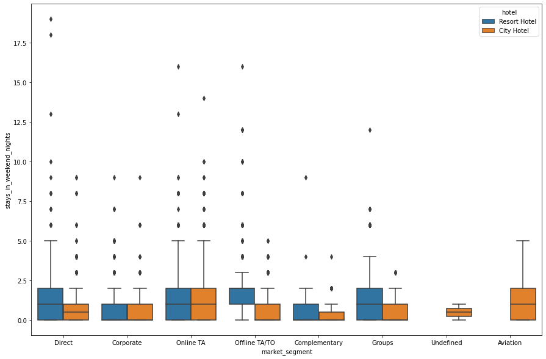

```python
plt.figure(figsize=(15,10))
sns.boxplot(x='market_segment',y='stays_in_weekend_nights',data=data,hue='hotel')
```

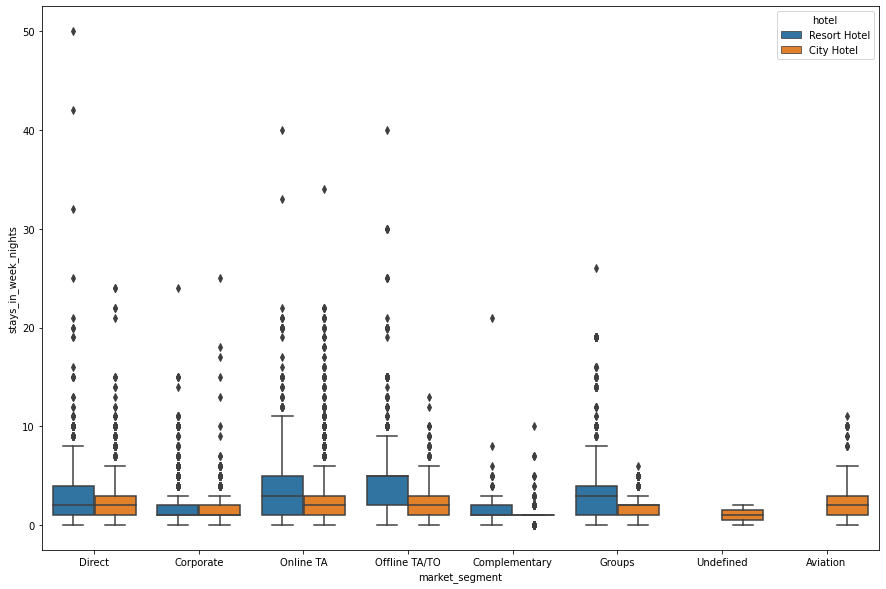

```python
plt.figure(figsize=(15,10))
sns.boxplot(x='market_segment',y='stays_in_week_nights',data=data,hue='hotel')
```

```python
data['meal'].value_counts()
```

```
BB           92236
HB           14458
SC           10549
Undefined     1169
FB             798
Name: meal, dtype: int64
```

```python
data['meal'].value_counts().index
```

```
Index(['BB', 'HB', 'SC', 'Undefined', 'FB'], dtype='object')
```

```python
# 'Hole' to make a donut chart
px.pie(data,values=data['meal'].value_counts(),names=data['meal'].value_counts().index,hole=0.5,title='What is the Most Popular Meal?')
```

[interactive chart not shown]

## Analyzing Relationship Between Special Guests and Cancellation

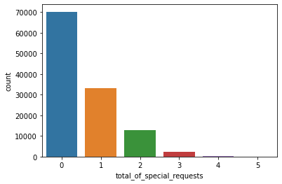

```python
# Majority of the guests have no special requests
sns.countplot(data['total_of_special_requests'])
```

```python
# Majority of the guests have no special requests
data['total_of_special_requests'].value_counts()
```

```
0    70201
1    33183
2    12952
3     2494
4      340
5       40
Name: total_of_special_requests, dtype: int64
```

```python
data['total_of_special_requests'].count()
```

```
119210
```

```python
# Creating a pivot table
pivot_data=data.groupby(['total_of_special_requests','is_canceled']).agg({'total_of_special_requests':'count'})
pivot_data
```

| total_of_special_requests | is_canceled | total_of_special_requests |
| --- | --- | --- |
| 0 | 0 | 36667 |
|  | 1 | 33534 |
| 1 | 0 | 25867 |
|  | 1 | 7316 |
| 2 | 0 | 10086 |
|  | 1 | 2866 |
| 3 | 0 | 2049 |
|  | 1 | 445 |
| 4 | 0 | 304 |
|  | 1 | 36 |
| 5 | 0 | 38 |
|  | 1 | 2 |

```python
pivot_data.unstack()
```

| is_canceled total_of_special_requests | total_of_special_requests 0 | total_of_special_requests 1 |
| --- | --- | --- |
| 0 | 36667 | 33534 |
| 1 | 25867 | 7316 |
| 2 | 10086 | 2866 |
| 3 | 2049 | 445 |
| 4 | 304 | 36 |
| 5 | 38 | 2 |

```python
# Rename the column to count
pivot=pivot_data.rename(columns={'total_of_special_requests':'count'}).unstack()
pivot
```

| is_canceled total_of_special_requests | count 0 | count 1 |
| --- | --- | --- |
| 0 | 36667 | 33534 |
| 1 | 25867 | 7316 |
| 2 | 10086 | 2866 |
| 3 | 2049 | 445 |
| 4 | 304 | 36 |
| 5 | 38 | 2 |

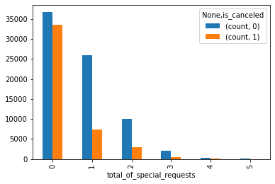

```python
pivot.plot(kind='bar')
```

From the bar chart above, we observed at 0 special request, cancellation is nearly as high as non-cancelled bookings. When there is 1 special request, number of cancellation dropped significantly. Indicating that the existence of special requests help to decrease cancellation.

## Most Busy Months

```python
rush_resort=data_resort['arrival_date_month'].value_counts().reset_index()
rush_resort.columns=['Month','Number of Guests']
rush_resort
```

|  | Month | Number of Guests |
| --- | --- | --- |
| 0 | August | 3257 |
| 1 | July | 3137 |
| 2 | October | 2575 |
| 3 | March | 2571 |
| 4 | April | 2550 |
| 5 | May | 2535 |
| 6 | February | 2308 |
| 7 | September | 2102 |
| 8 | June | 2037 |
| 9 | December | 2014 |
| 10 | November | 1975 |
| 11 | January | 1866 |

```python
rush_city=data_city['arrival_date_month'].value_counts().reset_index()
rush_city.columns=['Month','Number of Guests']
rush_city
```

|  | Month | Number of Guests |
| --- | --- | --- |
| 0 | August | 5367 |
| 1 | July | 4770 |
| 2 | May | 4568 |
| 3 | June | 4358 |
| 4 | October | 4326 |
| 5 | September | 4283 |
| 6 | March | 4049 |
| 7 | April | 4010 |
| 8 | February | 3051 |
| 9 | November | 2676 |
| 10 | December | 2377 |
| 11 | January | 2249 |

```python
# Merging dataframe
final_rush=rush_resort.merge(rush_city,on='Month')
final_rush.columns=['Month','Number of Guest for Resort Hotel','Number of Guest for City Hotel']
final_rush
```

|  | Month | Number of Guest for Resort Hotel | Number of Guest for City Hotel |
| --- | --- | --- | --- |
| 0 | August | 3257 | 5367 |
| 1 | July | 3137 | 4770 |
| 2 | October | 2575 | 4326 |
| 3 | March | 2571 | 4049 |
| 4 | April | 2550 | 4010 |
| 5 | May | 2535 | 4568 |
| 6 | February | 2308 | 3051 |
| 7 | September | 2102 | 4283 |
| 8 | June | 2037 | 4358 |
| 9 | December | 2014 | 2377 |
| 10 | November | 1975 | 2676 |
| 11 | January | 1866 | 2249 |

```python
# Sort month in order
import sort_dataframeby_monthorweek as sd
```

```python
final_rush2=sd.Sort_Dataframeby_Month(df=final_rush,monthcolumnname='Month')
final_rush2
```

|  | Month | Number of Guest for Resort Hotel | Number of Guest for City Hotel |
| --- | --- | --- | --- |
| 0 | January | 1866 | 2249 |
| 1 | February | 2308 | 3051 |
| 2 | March | 2571 | 4049 |
| 3 | April | 2550 | 4010 |
| 4 | May | 2535 | 4568 |
| 5 | June | 2037 | 4358 |
| 6 | July | 3137 | 4770 |
| 7 | August | 3257 | 5367 |
| 8 | September | 2102 | 4283 |
| 9 | October | 2575 | 4326 |
| 10 | November | 1975 | 2676 |
| 11 | December | 2014 | 2377 |

```python
px.line(data_frame=final_rush2,x='Month',y=['Number of Guest for Resort Hotel','Number of Guest for City Hotel'],title='Total Number of Guests Per Month')
```

[interactive chart not shown]

Summer appears to be the most busy period of the year for both hotels. Interestingly, while city hotel is more expensive than resort hotel in most of the months, city hotel still beats resort hotel in terms of booking guests. Also, though resort hotel sees a huge price surge during summer, resort hotel still experiences a booking surge in summer.

## Analyzing More About Customers

```python
filter2=data['is_canceled']==0
filter2
```

```
0          True
1          True
2          True
3          True
4          True
5          True
6          True
7          True
8         False
9         False
10        False
11         True
12         True
13         True
14         True
```

[output cut: 119196 more lines]

```python
clean_data=data[filter2]
clean_data.head()
```

|  | hotel | is_canceled | lead_time | arrival_date_year | arrival_date_month | arrival_date_week_number | arrival_date_day_of_month | stays_in_weekend_nights | stays_in_week_nights | adults | children | babies | meal | country | market_segment | distribution_channel | is_repeated_guest | previous_cancellations | previous_bookings_not_canceled | reserved_room_type | assigned_room_type | booking_changes | deposit_type | agent | company | days_in_waiting_list | customer_type | adr | required_car_parking_spaces | … |
| --- | --- | --- | --- | --- | --- | --- | --- | --- | --- | --- | --- | --- | --- | --- | --- | --- | --- | --- | --- | --- | --- | --- | --- | --- | --- | --- | --- | --- | --- | --- |
| 0 | Resort Hotel | 0 | 342 | 2015 | July | 27 | 1 | 0 | 0 | 2 | 0.0 | 0 | BB | PRT | Direct | Direct | 0 | 0 | 0 | C | C | 3 | No Deposit | 0.0 | 0.0 | 0 | Transient | 0.0 | 0 | … |
| 1 | Resort Hotel | 0 | 737 | 2015 | July | 27 | 1 | 0 | 0 | 2 | 0.0 | 0 | BB | PRT | Direct | Direct | 0 | 0 | 0 | C | C | 4 | No Deposit | 0.0 | 0.0 | 0 | Transient | 0.0 | 0 | … |
| 2 | Resort Hotel | 0 | 7 | 2015 | July | 27 | 1 | 0 | 1 | 1 | 0.0 | 0 | BB | GBR | Direct | Direct | 0 | 0 | 0 | A | C | 0 | No Deposit | 0.0 | 0.0 | 0 | Transient | 75.0 | 0 | … |
| 3 | Resort Hotel | 0 | 13 | 2015 | July | 27 | 1 | 0 | 1 | 1 | 0.0 | 0 | BB | GBR | Corporate | Corporate | 0 | 0 | 0 | A | A | 0 | No Deposit | 304.0 | 0.0 | 0 | Transient | 75.0 | 0 | … |
| 4 | Resort Hotel | 0 | 14 | 2015 | July | 27 | 1 | 0 | 2 | 2 | 0.0 | 0 | BB | GBR | Online TA | TA/TO | 0 | 0 | 0 | A | A | 0 | No Deposit | 240.0 | 0.0 | 0 | Transient | 98.0 | 0 | … |

```python
clean_data.shape
```

```
(75011, 32)
```

```python
filter3=data['is_canceled']==1
filter3
clean_data2=data[filter3]
clean_data2.head()
```

|  | hotel | is_canceled | lead_time | arrival_date_year | arrival_date_month | arrival_date_week_number | arrival_date_day_of_month | stays_in_weekend_nights | stays_in_week_nights | adults | children | babies | meal | country | market_segment | distribution_channel | is_repeated_guest | previous_cancellations | previous_bookings_not_canceled | reserved_room_type | assigned_room_type | booking_changes | deposit_type | agent | company | days_in_waiting_list | customer_type | adr | required_car_parking_spaces | … |
| --- | --- | --- | --- | --- | --- | --- | --- | --- | --- | --- | --- | --- | --- | --- | --- | --- | --- | --- | --- | --- | --- | --- | --- | --- | --- | --- | --- | --- | --- | --- |
| 8 | Resort Hotel | 1 | 85 | 2015 | July | 27 | 1 | 0 | 3 | 2 | 0.0 | 0 | BB | PRT | Online TA | TA/TO | 0 | 0 | 0 | A | A | 0 | No Deposit | 240.0 | 0.0 | 0 | Transient | 82.0 | 0 | … |
| 9 | Resort Hotel | 1 | 75 | 2015 | July | 27 | 1 | 0 | 3 | 2 | 0.0 | 0 | HB | PRT | Offline TA/TO | TA/TO | 0 | 0 | 0 | D | D | 0 | No Deposit | 15.0 | 0.0 | 0 | Transient | 105.5 | 0 | … |
| 10 | Resort Hotel | 1 | 23 | 2015 | July | 27 | 1 | 0 | 4 | 2 | 0.0 | 0 | BB | PRT | Online TA | TA/TO | 0 | 0 | 0 | E | E | 0 | No Deposit | 240.0 | 0.0 | 0 | Transient | 123.0 | 0 | … |
| 27 | Resort Hotel | 1 | 60 | 2015 | July | 27 | 1 | 2 | 5 | 2 | 0.0 | 0 | BB | PRT | Online TA | TA/TO | 0 | 0 | 0 | E | E | 0 | No Deposit | 240.0 | 0.0 | 0 | Transient | 107.0 | 0 | … |
| 32 | Resort Hotel | 1 | 96 | 2015 | July | 27 | 1 | 2 | 8 | 2 | 0.0 | 0 | BB | PRT | Direct | Direct | 0 | 0 | 0 | E | E | 0 | No Deposit | 0.0 | 0.0 | 0 | Transient | 108.3 | 0 | … |

```python
clean_data2.shape
```

```
(44199, 32)
```

```python
44199 + 75011
```

```
119210
```

```python
clean_data['total_nights']=clean_data['stays_in_weekend_nights'] + clean_data['stays_in_week_nights']
```

```python
# Ignore warnings
import warnings
from warnings import filterwarnings
filterwarnings('ignore')
```

```python
clean_data['total_nights']=clean_data['stays_in_weekend_nights'] + clean_data['stays_in_week_nights']
```

```python
stay=clean_data.groupby(['total_nights','hotel']).agg('count').reset_index()
stay
```

|  | total_nights | hotel | is_canceled | lead_time | arrival_date_year | arrival_date_month | arrival_date_week_number | arrival_date_day_of_month | stays_in_weekend_nights | stays_in_week_nights | adults | children | babies | meal | country | market_segment | distribution_channel | is_repeated_guest | previous_cancellations | previous_bookings_not_canceled | reserved_room_type | assigned_room_type | booking_changes | deposit_type | agent | company | days_in_waiting_list | customer_type | adr | … |
| --- | --- | --- | --- | --- | --- | --- | --- | --- | --- | --- | --- | --- | --- | --- | --- | --- | --- | --- | --- | --- | --- | --- | --- | --- | --- | --- | --- | --- | --- | --- |
| 0 | 0 | City Hotel | 251 | 251 | 251 | 251 | 251 | 251 | 251 | 251 | 251 | 251 | 251 | 251 | 251 | 251 | 251 | 251 | 251 | 251 | 251 | 251 | 251 | 251 | 251 | 251 | 251 | 251 | 251 | … |
| 1 | 0 | Resort Hotel | 371 | 371 | 371 | 371 | 371 | 371 | 371 | 371 | 371 | 371 | 371 | 371 | 371 | 371 | 371 | 371 | 371 | 371 | 371 | 371 | 371 | 371 | 371 | 371 | 371 | 371 | 371 | … |
| 2 | 1 | City Hotel | 9155 | 9155 | 9155 | 9155 | 9155 | 9155 | 9155 | 9155 | 9155 | 9155 | 9155 | 9155 | 9155 | 9155 | 9155 | 9155 | 9155 | 9155 | 9155 | 9155 | 9155 | 9155 | 9155 | 9155 | 9155 | 9155 | 9155 | … |
| 3 | 1 | Resort Hotel | 6579 | 6579 | 6579 | 6579 | 6579 | 6579 | 6579 | 6579 | 6579 | 6579 | 6579 | 6579 | 6579 | 6579 | 6579 | 6579 | 6579 | 6579 | 6579 | 6579 | 6579 | 6579 | 6579 | 6579 | 6579 | 6579 | 6579 | … |
| 4 | 2 | City Hotel | 10983 | 10983 | 10983 | 10983 | 10983 | 10983 | 10983 | 10983 | 10983 | 10983 | 10983 | 10983 | 10983 | 10983 | 10983 | 10983 | 10983 | 10983 | 10983 | 10983 | 10983 | 10983 | 10983 | 10983 | 10983 | 10983 | 10983 | … |
| 5 | 2 | Resort Hotel | 4488 | 4488 | 4488 | 4488 | 4488 | 4488 | 4488 | 4488 | 4488 | 4488 | 4488 | 4488 | 4488 | 4488 | 4488 | 4488 | 4488 | 4488 | 4488 | 4488 | 4488 | 4488 | 4488 | 4488 | 4488 | 4488 | 4488 | … |
| 6 | 3 | City Hotel | 11889 | 11889 | 11889 | 11889 | 11889 | 11889 | 11889 | 11889 | 11889 | 11889 | 11889 | 11889 | 11889 | 11889 | 11889 | 11889 | 11889 | 11889 | 11889 | 11889 | 11889 | 11889 | 11889 | 11889 | 11889 | 11889 | 11889 | … |
| 7 | 3 | Resort Hotel | 3828 | 3828 | 3828 | 3828 | 3828 | 3828 | 3828 | 3828 | 3828 | 3828 | 3828 | 3828 | 3828 | 3828 | 3828 | 3828 | 3828 | 3828 | 3828 | 3828 | 3828 | 3828 | 3828 | 3828 | 3828 | 3828 | 3828 | … |
| 8 | 4 | City Hotel | 7694 | 7694 | 7694 | 7694 | 7694 | 7694 | 7694 | 7694 | 7694 | 7694 | 7694 | 7694 | 7694 | 7694 | 7694 | 7694 | 7694 | 7694 | 7694 | 7694 | 7694 | 7694 | 7694 | 7694 | 7694 | 7694 | 7694 | … |
| 9 | 4 | Resort Hotel | 3321 | 3321 | 3321 | 3321 | 3321 | 3321 | 3321 | 3321 | 3321 | 3321 | 3321 | 3321 | 3321 | 3321 | 3321 | 3321 | 3321 | 3321 | 3321 | 3321 | 3321 | 3321 | 3321 | 3321 | 3321 | 3321 | 3321 | … |
| 10 | 5 | City Hotel | 3210 | 3210 | 3210 | 3210 | 3210 | 3210 | 3210 | 3210 | 3210 | 3210 | 3210 | 3210 | 3210 | 3210 | 3210 | 3210 | 3210 | 3210 | 3210 | 3210 | 3210 | 3210 | 3210 | 3210 | 3210 | 3210 | 3210 | … |
| 11 | 5 | Resort Hotel | 1899 | 1899 | 1899 | 1899 | 1899 | 1899 | 1899 | 1899 | 1899 | 1899 | 1899 | 1899 | 1899 | 1899 | 1899 | 1899 | 1899 | 1899 | 1899 | 1899 | 1899 | 1899 | 1899 | 1899 | 1899 | 1899 | 1899 | … |
| 12 | 6 | City Hotel | 1111 | 1111 | 1111 | 1111 | 1111 | 1111 | 1111 | 1111 | 1111 | 1111 | 1111 | 1111 | 1111 | 1111 | 1111 | 1111 | 1111 | 1111 | 1111 | 1111 | 1111 | 1111 | 1111 | 1111 | 1111 | 1111 | 1111 | … |
| 13 | 6 | Resort Hotel | 1205 | 1205 | 1205 | 1205 | 1205 | 1205 | 1205 | 1205 | 1205 | 1205 | 1205 | 1205 | 1205 | 1205 | 1205 | 1205 | 1205 | 1205 | 1205 | 1205 | 1205 | 1205 | 1205 | 1205 | 1205 | 1205 | 1205 | … |
| 14 | 7 | City Hotel | 1245 | 1245 | 1245 | 1245 | 1245 | 1245 | 1245 | 1245 | 1245 | 1245 | 1245 | 1245 | 1245 | 1245 | 1245 | 1245 | 1245 | 1245 | 1245 | 1245 | 1245 | 1245 | 1245 | 1245 | 1245 | 1245 | 1245 | … |
| 15 | 7 | Resort Hotel | 4434 | 4434 | 4434 | 4434 | 4434 | 4434 | 4434 | 4434 | 4434 | 4434 | 4434 | 4434 | 4434 | 4434 | 4434 | 4434 | 4434 | 4434 | 4434 | 4434 | 4434 | 4434 | 4434 | 4434 | 4434 | 4434 | 4434 | … |
| 16 | 8 | City Hotel | 205 | 205 | 205 | 205 | 205 | 205 | 205 | 205 | 205 | 205 | 205 | 205 | 205 | 205 | 205 | 205 | 205 | 205 | 205 | 205 | 205 | 205 | 205 | 205 | 205 | 205 | 205 | … |
| 17 | 8 | Resort Hotel | 509 | 509 | 509 | 509 | 509 | 509 | 509 | 509 | 509 | 509 | 509 | 509 | 509 | 509 | 509 | 509 | 509 | 509 | 509 | 509 | 509 | 509 | 509 | 509 | 509 | 509 | 509 | … |
| 18 | 9 | City Hotel | 119 | 119 | 119 | 119 | 119 | 119 | 119 | 119 | 119 | 119 | 119 | 119 | 119 | 119 | 119 | 119 | 119 | 119 | 119 | 119 | 119 | 119 | 119 | 119 | 119 | 119 | 119 | … |
| 19 | 9 | Resort Hotel | 408 | 408 | 408 | 408 | 408 | 408 | 408 | 408 | 408 | 408 | 408 | 408 | 408 | 408 | 408 | 408 | 408 | 408 | 408 | 408 | 408 | 408 | 408 | 408 | 408 | 408 | 408 | … |
| 20 | 10 | City Hotel | 80 | 80 | 80 | 80 | 80 | 80 | 80 | 80 | 80 | 80 | 80 | 80 | 80 | 80 | 80 | 80 | 80 | 80 | 80 | 80 | 80 | 80 | 80 | 80 | 80 | 80 | 80 | … |
| 21 | 10 | Resort Hotel | 699 | 699 | 699 | 699 | 699 | 699 | 699 | 699 | 699 | 699 | 699 | 699 | 699 | 699 | 699 | 699 | 699 | 699 | 699 | 699 | 699 | 699 | 699 | 699 | 699 | 699 | 699 | … |
| 22 | 11 | City Hotel | 33 | 33 | 33 | 33 | 33 | 33 | 33 | 33 | 33 | 33 | 33 | 33 | 33 | 33 | 33 | 33 | 33 | 33 | 33 | 33 | 33 | 33 | 33 | 33 | 33 | 33 | 33 | … |
| 23 | 11 | Resort Hotel | 240 | 240 | 240 | 240 | 240 | 240 | 240 | 240 | 240 | 240 | 240 | 240 | 240 | 240 | 240 | 240 | 240 | 240 | 240 | 240 | 240 | 240 | 240 | 240 | 240 | 240 | 240 | … |
| 24 | 12 | City Hotel | 33 | 33 | 33 | 33 | 33 | 33 | 33 | 33 | 33 | 33 | 33 | 33 | 33 | 33 | 33 | 33 | 33 | 33 | 33 | 33 | 33 | 33 | 33 | 33 | 33 | 33 | 33 | … |
| 25 | 12 | Resort Hotel | 89 | 89 | 89 | 89 | 89 | 89 | 89 | 89 | 89 | 89 | 89 | 89 | 89 | 89 | 89 | 89 | 89 | 89 | 89 | 89 | 89 | 89 | 89 | 89 | 89 | 89 | 89 | … |
| 26 | 13 | City Hotel | 15 | 15 | 15 | 15 | 15 | 15 | 15 | 15 | 15 | 15 | 15 | 15 | 15 | 15 | 15 | 15 | 15 | 15 | 15 | 15 | 15 | 15 | 15 | 15 | 15 | 15 | 15 | … |
| 27 | 13 | Resort Hotel | 75 | 75 | 75 | 75 | 75 | 75 | 75 | 75 | 75 | 75 | 75 | 75 | 75 | 75 | 75 | 75 | 75 | 75 | 75 | 75 | 75 | 75 | 75 | 75 | 75 | 75 | 75 | … |
| 28 | 14 | City Hotel | 26 | 26 | 26 | 26 | 26 | 26 | 26 | 26 | 26 | 26 | 26 | 26 | 26 | 26 | 26 | 26 | 26 | 26 | 26 | 26 | 26 | 26 | 26 | 26 | 26 | 26 | 26 | … |
| 29 | 14 | Resort Hotel | 630 | 630 | 630 | 630 | 630 | 630 | 630 | 630 | 630 | 630 | 630 | 630 | 630 | 630 | 630 | 630 | 630 | 630 | 630 | 630 | 630 | 630 | 630 | 630 | 630 | 630 | 630 | … |
| 30 | 15 | City Hotel | 14 | 14 | 14 | 14 | 14 | 14 | 14 | 14 | 14 | 14 | 14 | 14 | 14 | 14 | 14 | 14 | 14 | 14 | 14 | 14 | 14 | 14 | 14 | 14 | 14 | 14 | 14 | … |
| 31 | 15 | Resort Hotel | 23 | 23 | 23 | 23 | 23 | 23 | 23 | 23 | 23 | 23 | 23 | 23 | 23 | 23 | 23 | 23 | 23 | 23 | 23 | 23 | 23 | 23 | 23 | 23 | 23 | 23 | 23 | … |
| 32 | 16 | City Hotel | 6 | 6 | 6 | 6 | 6 | 6 | 6 | 6 | 6 | 6 | 6 | 6 | 6 | 6 | 6 | 6 | 6 | 6 | 6 | 6 | 6 | 6 | 6 | 6 | 6 | 6 | 6 | … |
| 33 | 16 | Resort Hotel | 12 | 12 | 12 | 12 | 12 | 12 | 12 | 12 | 12 | 12 | 12 | 12 | 12 | 12 | 12 | 12 | 12 | 12 | 12 | 12 | 12 | 12 | 12 | 12 | 12 | 12 | 12 | … |
| 34 | 17 | City Hotel | 4 | 4 | 4 | 4 | 4 | 4 | 4 | 4 | 4 | 4 | 4 | 4 | 4 | 4 | 4 | 4 | 4 | 4 | 4 | 4 | 4 | 4 | 4 | 4 | 4 | 4 | 4 | … |
| 35 | 17 | Resort Hotel | 11 | 11 | 11 | 11 | 11 | 11 | 11 | 11 | 11 | 11 | 11 | 11 | 11 | 11 | 11 | 11 | 11 | 11 | 11 | 11 | 11 | 11 | 11 | 11 | 11 | 11 | 11 | … |
| 36 | 18 | City Hotel | 1 | 1 | 1 | 1 | 1 | 1 | 1 | 1 | 1 | 1 | 1 | 1 | 1 | 1 | 1 | 1 | 1 | 1 | 1 | 1 | 1 | 1 | 1 | 1 | 1 | 1 | 1 | … |
| 37 | 18 | Resort Hotel | 5 | 5 | 5 | 5 | 5 | 5 | 5 | 5 | 5 | 5 | 5 | 5 | 5 | 5 | 5 | 5 | 5 | 5 | 5 | 5 | 5 | 5 | 5 | 5 | 5 | 5 | 5 | … |
| 38 | 19 | City Hotel | 2 | 2 | 2 | 2 | 2 | 2 | 2 | 2 | 2 | 2 | 2 | 2 | 2 | 2 | 2 | 2 | 2 | 2 | 2 | 2 | 2 | 2 | 2 | 2 | 2 | 2 | 2 | … |
| 39 | 19 | Resort Hotel | 4 | 4 | 4 | 4 | 4 | 4 | 4 | 4 | 4 | 4 | 4 | 4 | 4 | 4 | 4 | 4 | 4 | 4 | 4 | 4 | 4 | 4 | 4 | 4 | 4 | 4 | 4 | … |
| 40 | 20 | City Hotel | 1 | 1 | 1 | 1 | 1 | 1 | 1 | 1 | 1 | 1 | 1 | 1 | 1 | 1 | 1 | 1 | 1 | 1 | 1 | 1 | 1 | 1 | 1 | 1 | 1 | 1 | 1 | … |
| 41 | 21 | City Hotel | 1 | 1 | 1 | 1 | 1 | 1 | 1 | 1 | 1 | 1 | 1 | 1 | 1 | 1 | 1 | 1 | 1 | 1 | 1 | 1 | 1 | 1 | 1 | 1 | 1 | 1 | 1 | … |
| 42 | 21 | Resort Hotel | 35 | 35 | 35 | 35 | 35 | 35 | 35 | 35 | 35 | 35 | 35 | 35 | 35 | 35 | 35 | 35 | 35 | 35 | 35 | 35 | 35 | 35 | 35 | 35 | 35 | 35 | 35 | … |
| 43 | 22 | City Hotel | 2 | 2 | 2 | 2 | 2 | 2 | 2 | 2 | 2 | 2 | 2 | 2 | 2 | 2 | 2 | 2 | 2 | 2 | 2 | 2 | 2 | 2 | 2 | 2 | 2 | 2 | 2 | … |
| 44 | 22 | Resort Hotel | 7 | 7 | 7 | 7 | 7 | 7 | 7 | 7 | 7 | 7 | 7 | 7 | 7 | 7 | 7 | 7 | 7 | 7 | 7 | 7 | 7 | 7 | 7 | 7 | 7 | 7 | 7 | … |
| 45 | 23 | City Hotel | 1 | 1 | 1 | 1 | 1 | 1 | 1 | 1 | 1 | 1 | 1 | 1 | 1 | 1 | 1 | 1 | 1 | 1 | 1 | 1 | 1 | 1 | 1 | 1 | 1 | 1 | 1 | … |
| 46 | 23 | Resort Hotel | 1 | 1 | 1 | 1 | 1 | 1 | 1 | 1 | 1 | 1 | 1 | 1 | 1 | 1 | 1 | 1 | 1 | 1 | 1 | 1 | 1 | 1 | 1 | 1 | 1 | 1 | 1 | … |
| 47 | 24 | City Hotel | 1 | 1 | 1 | 1 | 1 | 1 | 1 | 1 | 1 | 1 | 1 | 1 | 1 | 1 | 1 | 1 | 1 | 1 | 1 | 1 | 1 | 1 | 1 | 1 | 1 | 1 | 1 | … |
| 48 | 25 | Resort Hotel | 14 | 14 | 14 | 14 | 14 | 14 | 14 | 14 | 14 | 14 | 14 | 14 | 14 | 14 | 14 | 14 | 14 | 14 | 14 | 14 | 14 | 14 | 14 | 14 | 14 | 14 | 14 | … |
| 49 | 28 | Resort Hotel | 22 | 22 | 22 | 22 | 22 | 22 | 22 | 22 | 22 | 22 | 22 | 22 | 22 | 22 | 22 | 22 | 22 | 22 | 22 | 22 | 22 | 22 | 22 | 22 | 22 | 22 | 22 | … |
| 50 | 29 | Resort Hotel | 2 | 2 | 2 | 2 | 2 | 2 | 2 | 2 | 2 | 2 | 2 | 2 | 2 | 2 | 2 | 2 | 2 | 2 | 2 | 2 | 2 | 2 | 2 | 2 | 2 | 2 | 2 | … |
| 51 | 30 | Resort Hotel | 2 | 2 | 2 | 2 | 2 | 2 | 2 | 2 | 2 | 2 | 2 | 2 | 2 | 2 | 2 | 2 | 2 | 2 | 2 | 2 | 2 | 2 | 2 | 2 | 2 | 2 | 2 | … |
| 52 | 34 | City Hotel | 1 | 1 | 1 | 1 | 1 | 1 | 1 | 1 | 1 | 1 | 1 | 1 | 1 | 1 | 1 | 1 | 1 | 1 | 1 | 1 | 1 | 1 | 1 | 1 | 1 | 1 | 1 | … |
| 53 | 35 | Resort Hotel | 5 | 5 | 5 | 5 | 5 | 5 | 5 | 5 | 5 | 5 | 5 | 5 | 5 | 5 | 5 | 5 | 5 | 5 | 5 | 5 | 5 | 5 | 5 | 5 | 5 | 5 | 5 | … |
| 54 | 38 | Resort Hotel | 1 | 1 | 1 | 1 | 1 | 1 | 1 | 1 | 1 | 1 | 1 | 1 | 1 | 1 | 1 | 1 | 1 | 1 | 1 | 1 | 1 | 1 | 1 | 1 | 1 | 1 | 1 | … |
| 55 | 42 | Resort Hotel | 3 | 3 | 3 | 3 | 3 | 3 | 3 | 3 | 3 | 3 | 3 | 3 | 3 | 3 | 3 | 3 | 3 | 3 | 3 | 3 | 3 | 3 | 3 | 3 | 3 | 3 | 3 | … |
| 56 | 45 | Resort Hotel | 1 | 1 | 1 | 1 | 1 | 1 | 1 | 1 | 1 | 1 | 1 | 1 | 1 | 1 | 1 | 1 | 1 | 1 | 1 | 1 | 1 | 1 | 1 | 1 | 1 | 1 | 1 | … |
| 57 | 46 | Resort Hotel | 1 | 1 | 1 | 1 | 1 | 1 | 1 | 1 | 1 | 1 | 1 | 1 | 1 | 1 | 1 | 1 | 1 | 1 | 1 | 1 | 1 | 1 | 1 | 1 | 1 | 1 | 1 | … |
| 58 | 48 | City Hotel | 1 | 1 | 1 | 1 | 1 | 1 | 1 | 1 | 1 | 1 | 1 | 1 | 1 | 1 | 1 | 1 | 1 | 1 | 1 | 1 | 1 | 1 | 1 | 1 | 1 | 1 | 1 | … |
| 59 | 56 | Resort Hotel | 1 | 1 | 1 | 1 | 1 | 1 | 1 | 1 | 1 | 1 | 1 | 1 | 1 | 1 | 1 | 1 | 1 | 1 | 1 | 1 | 1 | 1 | 1 | 1 | 1 | 1 | 1 | … |
| 60 | 60 | Resort Hotel | 1 | 1 | 1 | 1 | 1 | 1 | 1 | 1 | 1 | 1 | 1 | 1 | 1 | 1 | 1 | 1 | 1 | 1 | 1 | 1 | 1 | 1 | 1 | 1 | 1 | 1 | 1 | … |
| 61 | 69 | Resort Hotel | 1 | 1 | 1 | 1 | 1 | 1 | 1 | 1 | 1 | 1 | 1 | 1 | 1 | 1 | 1 | 1 | 1 | 1 | 1 | 1 | 1 | 1 | 1 | 1 | 1 | 1 | 1 | … |

```python
# Choose only the first 3 columns
stay=stay.iloc[:,0:3]
stay.head()
```

[output not shown]

```python
# Rename columns
stay=stay.rename(columns={'is_canceled': 'Number of Stays'})
stay.head()
```

|  | total_nights | hotel | Number of Stays |
| --- | --- | --- | --- |
| 0 | 0 | City Hotel | 251 |
| 1 | 0 | Resort Hotel | 371 |
| 2 | 1 | City Hotel | 9155 |
| 3 | 1 | Resort Hotel | 6579 |
| 4 | 2 | City Hotel | 10983 |

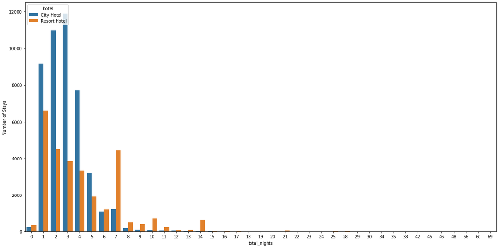

```python
plt.figure(figsize=(20,10))
sns.barplot(x='total_nights',y='Number of Stays',hue='hotel',data=stay)
```

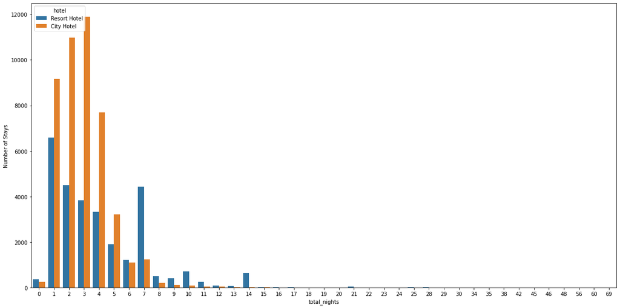

```python
# Use hue order to prioritize hotels color order
plt.figure(figsize=(20,10))
sns.barplot(x='total_nights',y='Number of Stays',hue='hotel',hue_order=['Resort Hotel','City Hotel'],data=stay)
```

From the chart above, we can conclude that for shorter stays from 1 to 5 nights, city hotel is preferred. However when number of stays surpass 5 nights, resort hotel is the preferred choice. Also, resort hotel has more bookings when it comes to 0 night.

```python
# Bookings by market segment
clean_data.columns
```

```
Index(['hotel', 'is_canceled', 'lead_time', 'arrival_date_year',
       'arrival_date_month', 'arrival_date_week_number',
       'arrival_date_day_of_month', 'stays_in_weekend_nights',
       'stays_in_week_nights', 'adults', 'children', 'babies', 'meal',
       'country', 'market_segment', 'distribution_channel',
       'is_repeated_guest', 'previous_cancellations',
       'previous_bookings_not_canceled', 'reserved_room_type',
       'assigned_room_type', 'booking_changes', 'deposit_type', 'agent',
       'company', 'days_in_waiting_list', 'customer_type', 'adr',
       'required_car_parking_spaces', 'total_of_special_requests',
       'reservation_status', 'reservation_status_date', 'total_nights'],
      dtype='object')
```

```python
clean_data['market_segment'].value_counts()
```

```
Online TA        35673
Offline TA/TO    15880
Direct           10648
Groups            7697
Corporate         4291
Complementary      639
Aviation           183
Name: market_segment, dtype: int64
```

```python
clean_data['market_segment'].value_counts().index
```

```
Index(['Online TA', 'Offline TA/TO', 'Direct', 'Groups', 'Corporate',
       'Complementary', 'Aviation'],
      dtype='object')
```

```python
px.pie(clean_data,values=clean_data['market_segment'].value_counts(),names=clean_data['market_segment'].value_counts().index,title='Bookings by Market Segment',hole=0.5)
```

[interactive chart not shown]

## How Many Bookings were Cancelled?

```python
cancel=data[data['is_canceled']==1]
cancel.head()
```

|  | hotel | is_canceled | lead_time | arrival_date_year | arrival_date_month | arrival_date_week_number | arrival_date_day_of_month | stays_in_weekend_nights | stays_in_week_nights | adults | children | babies | meal | country | market_segment | distribution_channel | is_repeated_guest | previous_cancellations | previous_bookings_not_canceled | reserved_room_type | assigned_room_type | booking_changes | deposit_type | agent | company | days_in_waiting_list | customer_type | adr | required_car_parking_spaces | … |
| --- | --- | --- | --- | --- | --- | --- | --- | --- | --- | --- | --- | --- | --- | --- | --- | --- | --- | --- | --- | --- | --- | --- | --- | --- | --- | --- | --- | --- | --- | --- |
| 8 | Resort Hotel | 1 | 85 | 2015 | July | 27 | 1 | 0 | 3 | 2 | 0.0 | 0 | BB | PRT | Online TA | TA/TO | 0 | 0 | 0 | A | A | 0 | No Deposit | 240.0 | 0.0 | 0 | Transient | 82.0 | 0 | … |
| 9 | Resort Hotel | 1 | 75 | 2015 | July | 27 | 1 | 0 | 3 | 2 | 0.0 | 0 | HB | PRT | Offline TA/TO | TA/TO | 0 | 0 | 0 | D | D | 0 | No Deposit | 15.0 | 0.0 | 0 | Transient | 105.5 | 0 | … |
| 10 | Resort Hotel | 1 | 23 | 2015 | July | 27 | 1 | 0 | 4 | 2 | 0.0 | 0 | BB | PRT | Online TA | TA/TO | 0 | 0 | 0 | E | E | 0 | No Deposit | 240.0 | 0.0 | 0 | Transient | 123.0 | 0 | … |
| 27 | Resort Hotel | 1 | 60 | 2015 | July | 27 | 1 | 2 | 5 | 2 | 0.0 | 0 | BB | PRT | Online TA | TA/TO | 0 | 0 | 0 | E | E | 0 | No Deposit | 240.0 | 0.0 | 0 | Transient | 107.0 | 0 | … |
| 32 | Resort Hotel | 1 | 96 | 2015 | July | 27 | 1 | 2 | 8 | 2 | 0.0 | 0 | BB | PRT | Direct | Direct | 0 | 0 | 0 | E | E | 0 | No Deposit | 0.0 | 0.0 | 0 | Transient | 108.3 | 0 | … |

```python
# How many resort hotel bookings were cancelled?
len(cancel[cancel['hotel']=='Resort Hotel'])
```

```
11120
```

```python
# How many city hotel bookings were cancelled?
len(cancel[cancel['hotel']=='City Hotel'])
```

```
33079
```

```python
px.pie(values=[11120,33079],names=['Resort Hotel Cancellations','City Hotel Cancellation'],hole=0.5)
```

[interactive chart not shown]

75% cancellations come from city hotel, while resort hotel accounted for 25% of the cancellations.